# Wall_study

```python
import numpy as np
import pandas as pd
import seaborn as sns
import matplotlib.pyplot as plt
from IPython.display import Image
from pathlib import Path
```

```python
# to display the all entire tables :
pd.set_option('display.max_rows', None)
pd.set_option('display.max_columns', None)

# or locally
# with pd.option_context('display.max_rows', None, 'display.max_columns', None):
#     display(df)

pd.options.display.float_format = '${:,.2f}'.format
```

```python
# replace the variable "this_folder" below by the output of pwd cell
```

```python
pwd
```

```
'U:\\WORK\\code_gpd\\data_analysis\\notebooks_danube\\dispositifs_study\\wall_study'
```

```python
this_folder = Path(r'U:\\WORK\\code_gpd\\data_analysis\\notebooks_danube\\dispositifs_study\\wall_study')
```

## Charge BDD Danube

```python
danube_csv_file_loc = r"U:\WORK\Danube\BDD\Present version\20220616_BddMAPUCE_MAP_V16.4-draft-export-utf8.csv"
```

```python
danube = pd.read_csv(danube_csv_file_loc, index_col="NUMERO_TYPOLOGIE")
# order by inputs in the first 4 columns and most interesting variables in thebeginning and end
col_ord = ['USAGE', 'NOM_TYPOLOGIE', 'PERIODE', 'TERRITOIRE',
           'DISPOSITIF_M1',
           'PORTEUR_M1', 'EP_PORTEUR_M1', 'ISOLANT_M1','EP_ISOLANT_M1',
           'REVETEMENT_INT_M1', 'EP_RI_M1', 'REVETEMENT_EXT_M1', 'EP_RE_M1',
           'DISPOSITIF_M2', 'PORTEUR_M2', 'EP_PORTEUR_M2',
           'ISOLANT_M2', 'EP_ISOLANT_M2', 'REVETEMENT_INT_M2', 'EP_RI2',
           'REVETEMENT_EXT_M2', 'EP_RE_M2', 'DISPOSITIF_M3', 'PORTEUR_M3',
           'EP_PORTEUR_M3', 'ISOLANT_M3', 'EP_ISOLANT_M3', 'REVETEMENT_INT_M3',
           'EP_RI_M3', 'REVETEMENT_EXT_M3', 'EP_RE_M3',
           'DISPOSITIF_T2', 'PORTEUR_T2', 'EP_PORTEUR_T2', 'ISOLANT_T2',
           'EP_ISOLANT_T2', 'REVETEMENT_INT_T2', 'EP_RI_T2', 'REVETEMENT_EXT_T2', 'EP_RE_T2',
           'TERRITOIRE_SHORT_ID', 'TERRITOIRE_DESC',
           'NUMERO_PERIODE', 'DATES', 'DATE_DEBUT', 'DATE_FIN',
           'POURCENTAGE_VITRAGE', 'TYPE_VITRAGE', 'PROTECTIONS_SOLAIRES',
           'VENTILATION','PERMEABILITE',
           'COUVERTURE_ROUTE','COMPACITE',
           'ID_PLANCHER', 'PLANCHER_RDC','EP_PLANCHER_RDC',
           'PLANCHER_INTERMEDIAIRE', 'EP_PLANCHER_INTER','PLANCHER',
           'DISPOSITIF_T1',
           'PORTEUR_T1', 'EP_PORTEUR_T1', 'ISOLANT_T1', 'EP_ISOLANT_T1',
           'REVETEMENT_INT_T1', 'EP_RI_T1', 'REVETEMENT_EXT_T1', 'EP_RE_T1',
    ]
danube = danube[col_ord].sort_values(['PERIODE', 'NOM_TYPOLOGIE',"USAGE","TERRITOIRE"])
danube.head()
# df = pd.read_csv(file_loc, sep=";", index_col="NUMERO_TYPOLOGIE")
```

| NUMERO_TYPOLOGIE | USAGE | NOM_TYPOLOGIE | PERIODE | TERRITOIRE | DISPOSITIF_M1 | PORTEUR_M1 | EP_PORTEUR_M1 | ISOLANT_M1 | EP_ISOLANT_M1 | REVETEMENT_INT_M1 | EP_RI_M1 | REVETEMENT_EXT_M1 | EP_RE_M1 | DISPOSITIF_M2 | PORTEUR_M2 | EP_PORTEUR_M2 | ISOLANT_M2 | EP_ISOLANT_M2 | REVETEMENT_INT_M2 | EP_RI2 | REVETEMENT_EXT_M2 | EP_RE_M2 | DISPOSITIF_M3 | PORTEUR_M3 | EP_PORTEUR_M3 | ISOLANT_M3 | EP_ISOLANT_M3 | REVETEMENT_INT_M3 | EP_RI_M3 | … |
| --- | --- | --- | --- | --- | --- | --- | --- | --- | --- | --- | --- | --- | --- | --- | --- | --- | --- | --- | --- | --- | --- | --- | --- | --- | --- | --- | --- | --- | --- | --- |
| AGR_BA_P1_TBR_TF | BATIMENT AGRICOLE | BA | P1 | FRANCE | PAV_M_P1_TBr_br | BRIQUE PLEINE | 60 | NON | 0 | ENDUIT | $2.00 | ENDUIT | 2 | ND | ND | 0 | ND | 0 | ND | $0.00 | ND | 0 | ND | ND | 0 | ND | 0 | ND | $0.00 | … |
| AGR_BA_P1_TBO_ARD | BATIMENT AGRICOLE | BA | P1 | FRANCE_BOIS_ARDOISE | PAV_M_P1_TBo-bo | BOIS | 50 | IR | 0 | NON | $0.00 | NON | 0 | ND | ND | 0 | ND | 0 | ND | $0.00 | ND | 0 | ND | ND | 0 | ND | 0 | ND | $0.00 | … |
| AGR_BA_P1_TBO_TUI | BATIMENT AGRICOLE | BA | P1 | FRANCE_BOIS_TUILE | PAV_M_P1_TBo-bo | BOIS | 50 | IR | 0 | NON | $0.00 | NON | 0 | ND | ND | 0 | ND | 0 | ND | $0.00 | ND | 0 | ND | ND | 0 | ND | 0 | ND | $0.00 | … |
| AGR_BA_P1_TBR_TUI | BATIMENT AGRICOLE | BA | P1 | FRANCE_BRIQUE_TUILE | PAV_M_P1_TBr_br | BRIQUE PLEINE | 60 | NON | 0 | ENDUIT | $2.00 | ENDUIT | 2 | ND | ND | 0 | ND | 0 | ND | $0.00 | ND | 0 | ND | ND | 0 | ND | 0 | ND | $0.00 | … |
| AGR_BA_P1_TCAL_ARD | BATIMENT AGRICOLE | BA | P1 | FRANCE_PIERRE_CALCAIRE_ARDOISE | PAV_M_P1_TPi_Cal | CALCAIRE | 80 | NON | 0 | NON | $0.00 | ENDUIT | 2 | ND | ND | 0 | ND | 0 | ND | $0.00 | ND | 0 | ND | ND | 0 | ND | 0 | ND | $0.00 | … |

## Calculate wall U-value

The calculation of the U value is based on the 3CL method, which depends on the type of wall and information available for the wall insulation and contruction period. The combinations of "PORTEUR" and "REVETEMENT_EXT", presented in the previous part, were associated to the 3CL construction techniques.

```python
disp_wall = pd.read_excel(r"DISPOSITIFS_MUR-export_avec_U0.xlsx")
disp_wall.head(2)
```

|  | DISPOSITIF | PORTEUR | EP_PORTEUR | ISOLANT | EP_ISOLANT | REVETEMENT_INT | EP_RI | REVETEMENT_EXT | EP_RE | U_0 |
| --- | --- | --- | --- | --- | --- | --- | --- | --- | --- | --- |
| 0 | IMM_M_P7_TN_TER_BE | BETON | 20 | ITE_LM | 16 | PLAQUE DE PLATRE | $1.30 | BARDAGE METAL | 2 | $2.90 |
| 1 | IMM_M_P2_TN_REL_BA | BETON ARME | 20 | NON | 0 | ENDUIT | $1.00 | ENDUIT | 2 | $2.90 |

```python
# defining period
disp_wall["period"] = disp_wall.DISPOSITIF.str.split(pat="_").str.get(2)
disp_wall.head(2)
disp_wall = disp_wall[list(disp_wall.columns[:-2]) +["period", "U_0"] ]
```

##### Conditions dispositif type

```python
cond_serre = disp_wall["REVETEMENT_EXT"].str.endswith("VITRAGE")
cond_non_is = disp_wall['EP_ISOLANT'] == 0
cond_is = disp_wall['EP_ISOLANT'] > 0
```

cond_dalle = disp_roof["PORTEUR3"] == 'DALLE BETON' cond_bois = disp_roof["PORTEUR3"] == 'STRUCTURE BOIS' cond_tuile = disp_roof.REVETEMENT_EXT3.str.startswith("TUILE") cond_metal_tole = disp_roof["REVETEMENT_EXT3"] == 'TOLE'

cond_is = disp_roof['EP_ISOLANT3'] > 0

### Non insulated wall and base value

#### Uw_0

- The values were calculated based on the wall type and thickness
- These values are already described in the file: DISPOSITIFS_MUR-export_avec_U0.xlsx

### Insulation unknown

#### Uw_inc

**Calculates Uph in case the presence of insulation is unknown**

- The values of P3 from 75-77 are always equal to those of "Autres" 78-82
- P6 has each time just one value for "Effet joule" et "Autres", which will facilitate the storage of both of them later

```python
this_folder
```

```
WindowsPath('U:/WORK/code_gpd/data_analysis/notebooks_danube/dispositifs_study/wall_study')
```

```python
isol_inc_path= this_folder / "3CL_tables" / "Presence_isolation_mur_inconnue_3CL.xlsx"
df_isol_inc = pd.read_excel(isol_inc_path,nrows=7, index_col=0)
df_isol_inc
```

| period | H1_joule | H1_autre | H2_joule | H2_autre | H3_joule | H3_autre |
| --- | --- | --- | --- | --- | --- | --- |
| P1 | $2.50 | $2.50 | $2.50 | $2.50 | $2.50 | $2.50 |
| P2 | $2.50 | $2.50 | $2.50 | $2.50 | $2.50 | $2.50 |
| P3 | $0.80 | $1.00 | $0.84 | $1.05 | $0.89 | $1.11 |
| P4 | $0.70 | $0.80 | $0.74 | $0.84 | $0.78 | $0.89 |
| P5 | $0.45 | $0.50 | $0.47 | $0.53 | $0.50 | $0.56 |
| P6 | $0.40 | $0.36 | $0.40 | $0.36 | $0.47 | $0.40 |
| P7 | $0.36 | $0.36 | $0.36 | $0.36 | $0.40 | $0.40 |

```python
dict_isol_inc = df_isol_inc.to_dict()
list(dict_isol_inc.keys())
```

```
['H1_joule', 'H1_autre', 'H2_joule', 'H2_autre', 'H3_joule', 'H3_autre']
```

```python
name_Uw_inc = ["Uw_inc_H1_joule",
                "Uw_inc_H1_autre",
                "Uw_inc_H2_joule",
                "Uw_inc_H2_autre",
                "Uw_inc_H3_joule",
                "Uw_inc_H3_autre",]
```

```python
inc_isolation = list(dict_isol_inc.keys())
inc_isolation
```

```
['H1_joule', 'H1_autre', 'H2_joule', 'H2_autre', 'H3_joule', 'H3_autre']
```

```python
dict_inc_isol = dict(zip(name_Uw_inc,inc_isolation))

for name_col in name_Uw_inc:
    # calculate based on the table and on the type of wall (combles/terraces)
    disp_wall[name_col] =  disp_wall['period'].map(dict_isol_inc[dict_inc_isol[name_col]])

    # correct P6 in the "autre" using P7 values
    # erase the values for serre
    disp_wall[name_col] = np.where(cond_serre,
                                   np.nan,
                                   disp_wall[name_col])
disp_wall.head()
```

|  | DISPOSITIF | PORTEUR | EP_PORTEUR | ISOLANT | EP_ISOLANT | REVETEMENT_INT | EP_RI | REVETEMENT_EXT | EP_RE | period | U_0 | Uw_inc_H1_joule | Uw_inc_H1_autre | Uw_inc_H2_joule | Uw_inc_H2_autre | Uw_inc_H3_joule | Uw_inc_H3_autre |
| --- | --- | --- | --- | --- | --- | --- | --- | --- | --- | --- | --- | --- | --- | --- | --- | --- | --- |
| 0 | IMM_M_P7_TN_TER_BE | BETON | 20 | ITE_LM | 16 | PLAQUE DE PLATRE | $1.30 | BARDAGE METAL | 2 | P7 | $2.90 | $0.36 | $0.36 | $0.36 | $0.36 | $0.40 | $0.40 |
| 1 | IMM_M_P2_TN_REL_BA | BETON ARME | 20 | NON | 0 | ENDUIT | $1.00 | ENDUIT | 2 | P2 | $2.90 | $2.50 | $2.50 | $2.50 | $2.50 | $2.50 | $2.50 |
| 2 | IMM_M_P2_TN_BB | BETON BANCHE | 20 | NON | 0 | ENDUIT | $1.00 | ENDUIT | 2 | P2 | $2.90 | $2.50 | $2.50 | $2.50 | $2.50 | $2.50 | $2.50 |
| 3 | IMM_M_P3_TN_BEPP | BETON BANCHE | 20 | ITE_LM | 6 | PLAQUE DE PLATRE | $1.30 | PANNEAU PREFA BETON | 15 | P3 | $2.90 | $0.80 | $1.00 | $0.84 | $1.05 | $0.89 | $1.11 |
| 4 | IMM_M_P5_TN_BB | BETON BANCHE | 20 | ITI_LM | 6 | PLAQUE DE PLATRE | $1.30 | ENDUIT | 2 | P5 | $2.90 | $0.45 | $0.50 | $0.47 | $0.53 | $0.50 | $0.56 |

### Insulated wall

```python
disp_wall.ISOLANT.unique()
```

```
array(['ITE_LM', 'NON', 'ITI_LM', 'ITI_AIR', 'IR'], dtype=object)
```

```python
disp_wall[disp_wall["ISOLANT"]=='ITI_AIR']
```

|  | DISPOSITIF | PORTEUR | EP_PORTEUR | ISOLANT | EP_ISOLANT | REVETEMENT_INT | EP_RI | REVETEMENT_EXT | EP_RE | period | U_0 | Uw_inc_H1_joule | Uw_inc_H1_autre | Uw_inc_H2_joule | Uw_inc_H2_autre | Uw_inc_H3_joule | Uw_inc_H3_autre |
| --- | --- | --- | --- | --- | --- | --- | --- | --- | --- | --- | --- | --- | --- | --- | --- | --- | --- |
| 22 | IMM_M_P3_TN_PA | PARPAING | 20 | ITI_AIR | 1 | CONTRE CLOISON | $1.30 | ENDUIT | 2 | P3 | $2.80 | $0.80 | $1.00 | $0.84 | $1.05 | $0.89 | $1.11 |
| 45 | IMM_M_P3_TN_BB | BETON BANCHE | 40 | ITI_AIR | 1 | CONTRE CLOISON | $1.30 | ENDUIT | 2 | P3 | $2.05 | $0.80 | $1.00 | $0.84 | $1.05 | $0.89 | $1.11 |
| 46 | IMM_M_P4_TN_BB | BETON BANCHE | 40 | ITI_AIR | 1 | CONTRE CLOISON | $1.30 | ENDUIT | 2 | P4 | $2.05 | $0.70 | $0.80 | $0.74 | $0.84 | $0.78 | $0.89 |
| 67 | IMM_M_P3_TBR | BRIQUE CREUSE | 25 | ITI_AIR | 1 | CONTRE CLOISON | $1.30 | PLAQUETTE BRIQUE | 2 | P3 | $1.70 | $0.80 | $1.00 | $0.84 | $1.05 | $0.89 | $1.11 |
| 68 | IMM_M_P4_TBR | BRIQUE CREUSE | 25 | ITI_AIR | 1 | CONTRE CLOISON | $1.30 | PLAQUETTE BRIQUE | 2 | P4 | $1.70 | $0.70 | $0.80 | $0.74 | $0.84 | $0.78 | $0.89 |
| 69 | IMM_M_P4_TN_BC | BRIQUE CREUSE | 25 | ITI_AIR | 1 | CONTRE CLOISON | $1.30 | ENDUIT | 2 | P4 | $1.70 | $0.70 | $0.80 | $0.74 | $0.84 | $0.78 | $0.89 |

```python
disp_wall[disp_wall["PORTEUR"]=='MONOMUR']
```

|  | DISPOSITIF | PORTEUR | EP_PORTEUR | ISOLANT | EP_ISOLANT | REVETEMENT_INT | EP_RI | REVETEMENT_EXT | EP_RE | period | U_0 | Uw_inc_H1_joule | Uw_inc_H1_autre | Uw_inc_H2_joule | Uw_inc_H2_autre | Uw_inc_H3_joule | Uw_inc_H3_autre |
| --- | --- | --- | --- | --- | --- | --- | --- | --- | --- | --- | --- | --- | --- | --- | --- | --- | --- |
| 113 | HAB_M_P6_TN_BR | MONOMUR | 37 | NON | 0 | ENDUIT | $2.00 | ENDUIT | 2 | P6 | $0.40 | $0.40 | $0.36 | $0.40 | $0.36 | $0.47 | $0.40 |
| 114 | PAV_M_P6_TN_BR | MONOMUR | 37 | NON | 0 | ENDUIT | $2.00 | ENDUIT | 2 | P6 | $0.40 | $0.40 | $0.36 | $0.40 | $0.36 | $0.47 | $0.40 |
| 115 | PAV_M_P7_TN_MON | MONOMUR | 40 | ITI_LM | 10 | PLAQUE DE PLATRE | $1.30 | ENDUIT | 2 | P7 | $0.40 | $0.36 | $0.36 | $0.36 | $0.36 | $0.40 | $0.40 |

#### Uw_R

```python
# generalization
def calculate_Uw_R(row, name_col, dict_cols):
    if row['EP_ISOLANT'] > 0:
        if (row['ISOLANT'] == "ITI_LM") or (row['ISOLANT'] == "ITE_LM"):
            conduct = 0.04
        if row['ISOLANT'] == 'ITE_POL':
            conduct = 0.03
        if row['ISOLANT'] == 'ITI_AIR':
            conduct = 0.025
        Uw_R = 1 / ( (1 / row[dict_cols[name_col]] ) + (row['EP_ISOLANT'] / 100) / conduct)

        return Uw_R
    else:
        return np.nan
```

```python
dict_cols_R = {"Uw_R":"U_0"}

disp_wall["Uw_R"] = disp_wall.apply(lambda x : calculate_Uw_R(x, "Uw_R", dict_cols_R), axis=1)
disp_wall
```

|  | DISPOSITIF | PORTEUR | EP_PORTEUR | ISOLANT | EP_ISOLANT | REVETEMENT_INT | EP_RI | REVETEMENT_EXT | EP_RE | period | U_0 | Uw_inc_H1_joule | Uw_inc_H1_autre | Uw_inc_H2_joule | Uw_inc_H2_autre | Uw_inc_H3_joule | Uw_inc_H3_autre | Uw_R |
| --- | --- | --- | --- | --- | --- | --- | --- | --- | --- | --- | --- | --- | --- | --- | --- | --- | --- | --- |
| 0 | IMM_M_P7_TN_TER_BE | BETON | 20 | ITE_LM | 16 | PLAQUE DE PLATRE | $1.30 | BARDAGE METAL | 2 | P7 | $2.90 | $0.36 | $0.36 | $0.36 | $0.36 | $0.40 | $0.40 | $0.23 |
| 1 | IMM_M_P2_TN_REL_BA | BETON ARME | 20 | NON | 0 | ENDUIT | $1.00 | ENDUIT | 2 | P2 | $2.90 | $2.50 | $2.50 | $2.50 | $2.50 | $2.50 | $2.50 | NaN |
| 2 | IMM_M_P2_TN_BB | BETON BANCHE | 20 | NON | 0 | ENDUIT | $1.00 | ENDUIT | 2 | P2 | $2.90 | $2.50 | $2.50 | $2.50 | $2.50 | $2.50 | $2.50 | NaN |
| 3 | IMM_M_P3_TN_BEPP | BETON BANCHE | 20 | ITE_LM | 6 | PLAQUE DE PLATRE | $1.30 | PANNEAU PREFA BETON | 15 | P3 | $2.90 | $0.80 | $1.00 | $0.84 | $1.05 | $0.89 | $1.11 | $0.54 |
| 4 | IMM_M_P5_TN_BB | BETON BANCHE | 20 | ITI_LM | 6 | PLAQUE DE PLATRE | $1.30 | ENDUIT | 2 | P5 | $2.90 | $0.45 | $0.50 | $0.47 | $0.53 | $0.50 | $0.56 | $0.54 |
| 5 | IMM_M_P6_TN_BB | BETON BANCHE | 20 | ITI_LM | 10 | PLAQUE DE PLATRE | $1.30 | ENDUIT | 2 | P6 | $2.90 | $0.40 | $0.36 | $0.40 | $0.36 | $0.47 | $0.40 | $0.35 |
| 6 | BGH_M_P2_TN_HAB_BE_BE | OSSATURE BETON | 0 | NON | 0 | PLAQUE DE PLATRE | $1.30 | PANNEAU PREFA BETON | 15 | P2 | $2.90 | $2.50 | $2.50 | $2.50 | $2.50 | $2.50 | $2.50 | NaN |
| 7 | BGH_M_P3_TN_HAB_BE_BE | OSSATURE BETON | 0 | ITI_LM | 5 | PLAQUE DE PLATRE | $1.30 | PANNEAU PREFA BETON | 15 | P3 | $2.90 | $0.80 | $1.00 | $0.84 | $1.05 | $0.89 | $1.11 | $0.63 |
| 8 | BGH_M_P4_TN_HAB_BE_BE | OSSATURE BETON | 0 | ITI_LM | 5 | PLAQUE DE PLATRE | $1.30 | PANNEAU PREFA BETON | 15 | P4 | $2.90 | $0.70 | $0.80 | $0.74 | $0.84 | $0.78 | $0.89 | $0.63 |
| 9 | BGH_M_P5_TN_HAB_BE_BE | OSSATURE BETON | 0 | ITI_LM | 10 | PLAQUE DE PLATRE | $1.30 | PANNEAU PREFA BETON | 15 | P5 | $2.90 | $0.45 | $0.50 | $0.47 | $0.53 | $0.50 | $0.56 | $0.35 |
| 10 | HAB_M_P2_TN_BEPP | OSSATURE BETON | 25 | NON | 0 | CONTRE CLOISON | $1.30 | PANNEAU PREFA BETON | 15 | P2 | $2.90 | $2.50 | $2.50 | $2.50 | $2.50 | $2.50 | $2.50 | NaN |
| 11 | HAB_M_P4_TN_PREF | OSSATURE BETON | 25 | ITE_LM | 10 | CONTRE CLOISON | $1.30 | PANNEAU PREFA BETON | 15 | P4 | $2.90 | $0.70 | $0.80 | $0.74 | $0.84 | $0.78 | $0.89 | $0.35 |
| 12 | IMM_M_P2_TN_BEPP | OSSATURE BETON | 0 | NON | 0 | PLAQUE DE PLATRE | $1.30 | PANNEAU PREFA BETON | 15 | P2 | $2.90 | $2.50 | $2.50 | $2.50 | $2.50 | $2.50 | $2.50 | NaN |
| 13 | IMM_M_P2_TN_COM_BE | OSSATURE BETON | 0 | NON | 0 | PLAQUE DE PLATRE | $1.30 | PANNEAU PREFA BETON | 15 | P2 | $2.90 | $2.50 | $2.50 | $2.50 | $2.50 | $2.50 | $2.50 | NaN |
| 14 | IMM_M_P2_TN_SCO_PRE | OSSATURE BETON | 0 | NON | 0 | NON | $0.00 | PANNEAU PREFA BETON | 15 | P2 | $2.90 | $2.50 | $2.50 | $2.50 | $2.50 | $2.50 | $2.50 | NaN |
| 15 | IMM_M_P3_TN_COM_BE | OSSATURE BETON | 0 | NON | 0 | PLAQUE DE PLATRE | $1.30 | PANNEAU PREFA BETON | 15 | P3 | $2.90 | $0.80 | $1.00 | $0.84 | $1.05 | $0.89 | $1.11 | NaN |
| 16 | IMM_M_P3_TN_SCO_PRE | OSSATURE BETON | 0 | NON | 0 | NON | $0.00 | PANNEAU PREFA BETON | 15 | P3 | $2.90 | $0.80 | $1.00 | $0.84 | $1.05 | $0.89 | $1.11 | NaN |
| 17 | IMM_M_P4_TN_PREF | OSSATURE BETON | 0 | ITE_LM | 6 | PLAQUE DE PLATRE | $1.30 | PANNEAU PREFA BETON | 15 | P4 | $2.90 | $0.70 | $0.80 | $0.74 | $0.84 | $0.78 | $0.89 | $0.54 |
| 18 | HAB_M_P1_TBo_pi | OSSATURE BOIS | 0 | NON | 0 | NON | $0.00 | PIERRE | 25 | P1 | $2.85 | $2.50 | $2.50 | $2.50 | $2.50 | $2.50 | $2.50 | NaN |
| 19 | HAB_M_P2_TN_PA | PARPAING | 20 | NON | 0 | NON | $0.00 | ENDUIT | 2 | P2 | $2.80 | $2.50 | $2.50 | $2.50 | $2.50 | $2.50 | $2.50 | NaN |
| 20 | HAB_M_P5_TN_PA | PARPAING | 20 | ITI_LM | 6 | CONTRE CLOISON | $1.30 | ENDUIT | 2 | P5 | $2.80 | $0.45 | $0.50 | $0.47 | $0.53 | $0.50 | $0.56 | $0.54 |
| 21 | IMM_M_P2_TN_PA | PARPAING | 20 | NON | 0 | CONTRE CLOISON | $1.30 | ENDUIT | 2 | P2 | $2.80 | $2.50 | $2.50 | $2.50 | $2.50 | $2.50 | $2.50 | NaN |
| 22 | IMM_M_P3_TN_PA | PARPAING | 20 | ITI_AIR | 1 | CONTRE CLOISON | $1.30 | ENDUIT | 2 | P3 | $2.80 | $0.80 | $1.00 | $0.84 | $1.05 | $0.89 | $1.11 | $1.32 |
| 23 | IMM_M_P3_TPI | PARPAING | 25 | NON | 0 | CONTRE CLOISON | $1.30 | PIERRE | 20 | P3 | $2.80 | $0.80 | $1.00 | $0.84 | $1.05 | $0.89 | $1.11 | NaN |
| 24 | IMM_M_P4_TPI | PARPAING | 20 | ITI_LM | 5 | PLAQUE DE PLATRE | $1.30 | PIERRE | 15 | P4 | $2.80 | $0.70 | $0.80 | $0.74 | $0.84 | $0.78 | $0.89 | $0.62 |
| 25 | IMM_M_P7_TN_TER_PAR | PARPAING | 20 | ITI_LM | 16 | PLAQUE DE PLATRE | $1.30 | ENDUIT | 2 | P7 | $2.80 | $0.36 | $0.36 | $0.36 | $0.36 | $0.40 | $0.40 | $0.23 |
| 26 | PAV_M_P2_TN_PA | PARPAING | 20 | NON | 0 | PLAQUE DE PLATRE | $1.30 | ENDUIT | 2 | P2 | $2.80 | $2.50 | $2.50 | $2.50 | $2.50 | $2.50 | $2.50 | NaN |
| 27 | PAV_M_P2_TPI | PARPAING | 20 | NON | 0 | PLAQUE DE PLATRE | $1.30 | PIERRE | 20 | P2 | $2.80 | $2.50 | $2.50 | $2.50 | $2.50 | $2.50 | $2.50 | NaN |
| 28 | PAV_M_P3_TN_PA | PARPAING | 20 | ITI_LM | 6 | PLAQUE DE PLATRE | $1.30 | ENDUIT | 2 | P3 | $2.80 | $0.80 | $1.00 | $0.84 | $1.05 | $0.89 | $1.11 | $0.54 |
| 29 | PAV_M_P4_TN_PA | PARPAING | 20 | ITI_LM | 5 | PLAQUE DE PLATRE | $1.30 | ENDUIT | 2 | P4 | $2.80 | $0.70 | $0.80 | $0.74 | $0.84 | $0.78 | $0.89 | $0.62 |

[output cut: 93 more lines]

```python
disp_wall[disp_wall["ISOLANT"]=='ITI_AIR']
```

|  | DISPOSITIF | PORTEUR | EP_PORTEUR | ISOLANT | EP_ISOLANT | REVETEMENT_INT | EP_RI | REVETEMENT_EXT | EP_RE | period | U_0 | Uw_inc_H1_joule | Uw_inc_H1_autre | Uw_inc_H2_joule | Uw_inc_H2_autre | Uw_inc_H3_joule | Uw_inc_H3_autre | Uw_R |
| --- | --- | --- | --- | --- | --- | --- | --- | --- | --- | --- | --- | --- | --- | --- | --- | --- | --- | --- |
| 22 | IMM_M_P3_TN_PA | PARPAING | 20 | ITI_AIR | 1 | CONTRE CLOISON | $1.30 | ENDUIT | 2 | P3 | $2.80 | $0.80 | $1.00 | $0.84 | $1.05 | $0.89 | $1.11 | $1.32 |
| 45 | IMM_M_P3_TN_BB | BETON BANCHE | 40 | ITI_AIR | 1 | CONTRE CLOISON | $1.30 | ENDUIT | 2 | P3 | $2.05 | $0.80 | $1.00 | $0.84 | $1.05 | $0.89 | $1.11 | $1.13 |
| 46 | IMM_M_P4_TN_BB | BETON BANCHE | 40 | ITI_AIR | 1 | CONTRE CLOISON | $1.30 | ENDUIT | 2 | P4 | $2.05 | $0.70 | $0.80 | $0.74 | $0.84 | $0.78 | $0.89 | $1.13 |
| 67 | IMM_M_P3_TBR | BRIQUE CREUSE | 25 | ITI_AIR | 1 | CONTRE CLOISON | $1.30 | PLAQUETTE BRIQUE | 2 | P3 | $1.70 | $0.80 | $1.00 | $0.84 | $1.05 | $0.89 | $1.11 | $1.01 |
| 68 | IMM_M_P4_TBR | BRIQUE CREUSE | 25 | ITI_AIR | 1 | CONTRE CLOISON | $1.30 | PLAQUETTE BRIQUE | 2 | P4 | $1.70 | $0.70 | $0.80 | $0.74 | $0.84 | $0.78 | $0.89 | $1.01 |
| 69 | IMM_M_P4_TN_BC | BRIQUE CREUSE | 25 | ITI_AIR | 1 | CONTRE CLOISON | $1.30 | ENDUIT | 2 | P4 | $1.70 | $0.70 | $0.80 | $0.74 | $0.84 | $0.78 | $0.89 | $1.01 |

#### Uw_E

```python
def calculate_Uw_E(row, name_col, dict_cols):
    if row['EP_ISOLANT'] > 0:
        Uw_E = 1 / ( (1 / row[dict_cols[name_col]] ) + (row['EP_ISOLANT'] / 100) / 0.04)

        return Uw_E
    else:
        return np.nan
```

```python
dict_cols_E = {"Uw_E":"U_0"}

disp_wall["Uw_E"] = disp_wall.apply(lambda x : calculate_Uw_E(x, "Uw_E", dict_cols_E), axis=1)
```

```python
disp_wall[disp_wall["ISOLANT"]=='ITI_AIR'][
    ['DISPOSITIF', 'PORTEUR', 'REVETEMENT_EXT', 'EP_ISOLANT', "Uw_R", "Uw_E"]]
```

|  | DISPOSITIF | PORTEUR | REVETEMENT_EXT | EP_ISOLANT | Uw_R | Uw_E |
| --- | --- | --- | --- | --- | --- | --- |
| 22 | IMM_M_P3_TN_PA | PARPAING | ENDUIT | 1 | $1.32 | $1.65 |
| 45 | IMM_M_P3_TN_BB | BETON BANCHE | ENDUIT | 1 | $1.13 | $1.36 |
| 46 | IMM_M_P4_TN_BB | BETON BANCHE | ENDUIT | 1 | $1.13 | $1.36 |
| 67 | IMM_M_P3_TBR | BRIQUE CREUSE | PLAQUETTE BRIQUE | 1 | $1.01 | $1.19 |
| 68 | IMM_M_P4_TBR | BRIQUE CREUSE | PLAQUETTE BRIQUE | 1 | $1.01 | $1.19 |
| 69 | IMM_M_P4_TN_BC | BRIQUE CREUSE | ENDUIT | 1 | $1.01 | $1.19 |

#### Uw_anne

**Calculates Uw in case the it is insulated, but only the year of the insulation is known**

```
Since we are trying to caractherize only the non renovateed buildings, we consider that the insulation year is equal to the construction year
```

```python
isol_annee_path = this_folder / "3CL_tables" / "Anee_isolation_mur_connue_3CL.xlsx"
df_isol_annee = pd.read_excel(isol_annee_path,nrows=5, index_col=0 )
df_isol_annee
# les colonnes "option2" sont pour les périodes P3 et P6 qui continnent 2 périodes du tableau ci-dessus
```

| period | H1 | H1_option2 | H2 | H2_option2 | H3 | H3_option2 |
| --- | --- | --- | --- | --- | --- | --- |
| P3 | $1.00 | $0.80 | $1.05 | $0.84 | $1.11 | $0.89 |
| P4 | $0.70 | NaN | $0.74 | NaN | $0.78 | NaN |
| P5 | $0.45 | NaN | $0.47 | NaN | $0.50 | NaN |
| P6 | $0.40 | $0.36 | $0.40 | $0.36 | $0.47 | $0.40 |
| P7 | $0.36 | NaN | $0.36 | NaN | $0.40 | NaN |

```python
dict_isol_annee = df_isol_annee.to_dict()
dict_isol_annee
```

```
{'H1': {'P3': 1.0, 'P4': 0.7, 'P5': 0.45, 'P6': 0.4, 'P7': 0.36},
 'H1_option2': {'P3': 0.8, 'P4': nan, 'P5': nan, 'P6': 0.36, 'P7': nan},
 'H2': {'P3': 1.05, 'P4': 0.74, 'P5': 0.47, 'P6': 0.4, 'P7': 0.36},
 'H2_option2': {'P3': 0.84, 'P4': nan, 'P5': nan, 'P6': 0.36, 'P7': nan},
 'H3': {'P3': 1.11, 'P4': 0.78, 'P5': 0.5, 'P6': 0.47, 'P7': 0.4},
 'H3_option2': {'P3': 0.89, 'P4': nan, 'P5': nan, 'P6': 0.4, 'P7': nan}}
```

```python
list(dict_isol_annee.keys())
```

```
['H1', 'H1_option2', 'H2', 'H2_option2', 'H3', 'H3_option2']
```

```python
name_Uw_annee = ["Uw_annee_H1",
                "Uw_annee_H1_option2",
                "Uw_annee_H2",
                "Uw_annee_H2_option2",
                "Uw_annee_H3",
                "Uw_annee_H3_option2",]
```

```python
annee = list(dict_isol_annee.keys())
annee
```

```
['H1', 'H1_option2', 'H2', 'H2_option2', 'H3', 'H3_option2']
```

```python
name_Uw_annee
```

```
['Uw_annee_H1',
 'Uw_annee_H1_option2',
 'Uw_annee_H2',
 'Uw_annee_H2_option2',
 'Uw_annee_H3',
 'Uw_annee_H3_option2']
```

```python
dict_an = dict(zip(name_Uw_annee,annee))

for name_col in name_Uw_annee:
    # calculate based on the table and on the type of roof (combles/terraces)
    disp_wall[name_col] = disp_wall['period'].map(dict_isol_annee[dict_an[name_col]])
    # erase the values for serre
    disp_wall[name_col] = np.where(cond_serre,
                                   np.nan,
                                   disp_wall[name_col])

    # erase the values for non insulated roof
    disp_wall[name_col] = np.where(cond_non_is,
                                   np.nan,
                                   disp_wall[name_col])
```

```python
check_annee = disp_wall[["DISPOSITIF","PORTEUR","REVETEMENT_EXT"]+name_Uw_annee]
# check_annee.to_excel("check_Uw_annee.xlsx")
```

```python
check_annee
```

|  | DISPOSITIF | PORTEUR | REVETEMENT_EXT | Uw_annee_H1 | Uw_annee_H1_option2 | Uw_annee_H2 | Uw_annee_H2_option2 | Uw_annee_H3 | Uw_annee_H3_option2 |
| --- | --- | --- | --- | --- | --- | --- | --- | --- | --- |
| 0 | IMM_M_P7_TN_TER_BE | BETON | BARDAGE METAL | $0.36 | NaN | $0.36 | NaN | $0.40 | NaN |
| 1 | IMM_M_P2_TN_REL_BA | BETON ARME | ENDUIT | NaN | NaN | NaN | NaN | NaN | NaN |
| 2 | IMM_M_P2_TN_BB | BETON BANCHE | ENDUIT | NaN | NaN | NaN | NaN | NaN | NaN |
| 3 | IMM_M_P3_TN_BEPP | BETON BANCHE | PANNEAU PREFA BETON | $1.00 | $0.80 | $1.05 | $0.84 | $1.11 | $0.89 |
| 4 | IMM_M_P5_TN_BB | BETON BANCHE | ENDUIT | $0.45 | NaN | $0.47 | NaN | $0.50 | NaN |
| 5 | IMM_M_P6_TN_BB | BETON BANCHE | ENDUIT | $0.40 | $0.36 | $0.40 | $0.36 | $0.47 | $0.40 |
| 6 | BGH_M_P2_TN_HAB_BE_BE | OSSATURE BETON | PANNEAU PREFA BETON | NaN | NaN | NaN | NaN | NaN | NaN |
| 7 | BGH_M_P3_TN_HAB_BE_BE | OSSATURE BETON | PANNEAU PREFA BETON | $1.00 | $0.80 | $1.05 | $0.84 | $1.11 | $0.89 |
| 8 | BGH_M_P4_TN_HAB_BE_BE | OSSATURE BETON | PANNEAU PREFA BETON | $0.70 | NaN | $0.74 | NaN | $0.78 | NaN |
| 9 | BGH_M_P5_TN_HAB_BE_BE | OSSATURE BETON | PANNEAU PREFA BETON | $0.45 | NaN | $0.47 | NaN | $0.50 | NaN |
| 10 | HAB_M_P2_TN_BEPP | OSSATURE BETON | PANNEAU PREFA BETON | NaN | NaN | NaN | NaN | NaN | NaN |
| 11 | HAB_M_P4_TN_PREF | OSSATURE BETON | PANNEAU PREFA BETON | $0.70 | NaN | $0.74 | NaN | $0.78 | NaN |
| 12 | IMM_M_P2_TN_BEPP | OSSATURE BETON | PANNEAU PREFA BETON | NaN | NaN | NaN | NaN | NaN | NaN |
| 13 | IMM_M_P2_TN_COM_BE | OSSATURE BETON | PANNEAU PREFA BETON | NaN | NaN | NaN | NaN | NaN | NaN |
| 14 | IMM_M_P2_TN_SCO_PRE | OSSATURE BETON | PANNEAU PREFA BETON | NaN | NaN | NaN | NaN | NaN | NaN |
| 15 | IMM_M_P3_TN_COM_BE | OSSATURE BETON | PANNEAU PREFA BETON | NaN | NaN | NaN | NaN | NaN | NaN |
| 16 | IMM_M_P3_TN_SCO_PRE | OSSATURE BETON | PANNEAU PREFA BETON | NaN | NaN | NaN | NaN | NaN | NaN |
| 17 | IMM_M_P4_TN_PREF | OSSATURE BETON | PANNEAU PREFA BETON | $0.70 | NaN | $0.74 | NaN | $0.78 | NaN |
| 18 | HAB_M_P1_TBo_pi | OSSATURE BOIS | PIERRE | NaN | NaN | NaN | NaN | NaN | NaN |
| 19 | HAB_M_P2_TN_PA | PARPAING | ENDUIT | NaN | NaN | NaN | NaN | NaN | NaN |
| 20 | HAB_M_P5_TN_PA | PARPAING | ENDUIT | $0.45 | NaN | $0.47 | NaN | $0.50 | NaN |
| 21 | IMM_M_P2_TN_PA | PARPAING | ENDUIT | NaN | NaN | NaN | NaN | NaN | NaN |
| 22 | IMM_M_P3_TN_PA | PARPAING | ENDUIT | $1.00 | $0.80 | $1.05 | $0.84 | $1.11 | $0.89 |
| 23 | IMM_M_P3_TPI | PARPAING | PIERRE | NaN | NaN | NaN | NaN | NaN | NaN |
| 24 | IMM_M_P4_TPI | PARPAING | PIERRE | $0.70 | NaN | $0.74 | NaN | $0.78 | NaN |
| 25 | IMM_M_P7_TN_TER_PAR | PARPAING | ENDUIT | $0.36 | NaN | $0.36 | NaN | $0.40 | NaN |
| 26 | PAV_M_P2_TN_PA | PARPAING | ENDUIT | NaN | NaN | NaN | NaN | NaN | NaN |
| 27 | PAV_M_P2_TPI | PARPAING | PIERRE | NaN | NaN | NaN | NaN | NaN | NaN |
| 28 | PAV_M_P3_TN_PA | PARPAING | ENDUIT | $1.00 | $0.80 | $1.05 | $0.84 | $1.11 | $0.89 |
| 29 | PAV_M_P4_TN_PA | PARPAING | ENDUIT | $0.70 | NaN | $0.74 | NaN | $0.78 | NaN |

[output cut: 93 more lines]

```python
check_annee.iloc[-6:]
```

|  | DISPOSITIF | PORTEUR | REVETEMENT_EXT | Uw_annee_H1 | Uw_annee_H1_option2 | Uw_annee_H2 | Uw_annee_H2_option2 | Uw_annee_H3 | Uw_annee_H3_option2 |
| --- | --- | --- | --- | --- | --- | --- | --- | --- | --- |
| 117 | SER_M_P2_TN | OSSATURE METALLIQUE | SIMPLE VITRAGE | NaN | NaN | NaN | NaN | NaN | NaN |
| 118 | SER_M_P3_TN | OSSATURE METALLIQUE | SIMPLE VITRAGE | NaN | NaN | NaN | NaN | NaN | NaN |
| 119 | SER_M_P4_TN | OSSATURE METALLIQUE | SIMPLE VITRAGE | NaN | NaN | NaN | NaN | NaN | NaN |
| 120 | SER_M_P5_TN | OSSATURE METALLIQUE | DOUBLE VITRAGE | NaN | NaN | NaN | NaN | NaN | NaN |
| 121 | SER_M_P6_TN | OSSATURE METALLIQUE | DOUBLE VITRAGE | NaN | NaN | NaN | NaN | NaN | NaN |
| 122 | SER_M_P7_TN | OSSATURE METALLIQUE | DOUBLE VITRAGE | NaN | NaN | NaN | NaN | NaN | NaN |

### Cols min max

```python
disp_wall.columns
```

```
Index(['DISPOSITIF', 'PORTEUR', 'EP_PORTEUR', 'ISOLANT', 'EP_ISOLANT',
       'REVETEMENT_INT', 'EP_RI', 'REVETEMENT_EXT', 'EP_RE', 'period', 'U_0',
       'Uw_inc_H1_joule', 'Uw_inc_H1_autre', 'Uw_inc_H2_joule',
       'Uw_inc_H2_autre', 'Uw_inc_H3_joule', 'Uw_inc_H3_autre', 'Uw_R', 'Uw_E',
       'Uw_annee_H1', 'Uw_annee_H1_option2', 'Uw_annee_H2',
       'Uw_annee_H2_option2', 'Uw_annee_H3', 'Uw_annee_H3_option2'],
      dtype='object')
```

```python
cols_Uw_non_isole = disp_wall.columns[10:17]
cols_Uw_non_isole
```

```
Index(['U_0', 'Uw_inc_H1_joule', 'Uw_inc_H1_autre', 'Uw_inc_H2_joule',
       'Uw_inc_H2_autre', 'Uw_inc_H3_joule', 'Uw_inc_H3_autre'],
      dtype='object')
```

```python
cols_Uw_isole = disp_wall.columns[11:]
cols_Uw_isole
```

```
Index(['Uw_inc_H1_joule', 'Uw_inc_H1_autre', 'Uw_inc_H2_joule',
       'Uw_inc_H2_autre', 'Uw_inc_H3_joule', 'Uw_inc_H3_autre', 'Uw_R', 'Uw_E',
       'Uw_annee_H1', 'Uw_annee_H1_option2', 'Uw_annee_H2',
       'Uw_annee_H2_option2', 'Uw_annee_H3', 'Uw_annee_H3_option2'],
      dtype='object')
```

```python
disp_wall["Uw_min"] = np.where(cond_is,
                                disp_wall[cols_Uw_isole].T.min(),
                                disp_wall[cols_Uw_non_isole].T.min())

disp_wall["Uw_max"] = np.where(cond_is,
                                disp_wall[cols_Uw_isole].T.max(),
                                disp_wall[cols_Uw_non_isole].T.max())
```

```python
disp_wall[["DISPOSITIF","PORTEUR","REVETEMENT_EXT","EP_ISOLANT", "Uw_min", "Uw_max"]]
```

|  | DISPOSITIF | PORTEUR | REVETEMENT_EXT | EP_ISOLANT | Uw_min | Uw_max |
| --- | --- | --- | --- | --- | --- | --- |
| 0 | IMM_M_P7_TN_TER_BE | BETON | BARDAGE METAL | 16 | $0.23 | $0.40 |
| 1 | IMM_M_P2_TN_REL_BA | BETON ARME | ENDUIT | 0 | $2.50 | $2.90 |
| 2 | IMM_M_P2_TN_BB | BETON BANCHE | ENDUIT | 0 | $2.50 | $2.90 |
| 3 | IMM_M_P3_TN_BEPP | BETON BANCHE | PANNEAU PREFA BETON | 6 | $0.54 | $1.11 |
| 4 | IMM_M_P5_TN_BB | BETON BANCHE | ENDUIT | 6 | $0.45 | $0.56 |
| 5 | IMM_M_P6_TN_BB | BETON BANCHE | ENDUIT | 10 | $0.35 | $0.47 |
| 6 | BGH_M_P2_TN_HAB_BE_BE | OSSATURE BETON | PANNEAU PREFA BETON | 0 | $2.50 | $2.90 |
| 7 | BGH_M_P3_TN_HAB_BE_BE | OSSATURE BETON | PANNEAU PREFA BETON | 5 | $0.63 | $1.11 |
| 8 | BGH_M_P4_TN_HAB_BE_BE | OSSATURE BETON | PANNEAU PREFA BETON | 5 | $0.63 | $0.89 |
| 9 | BGH_M_P5_TN_HAB_BE_BE | OSSATURE BETON | PANNEAU PREFA BETON | 10 | $0.35 | $0.56 |
| 10 | HAB_M_P2_TN_BEPP | OSSATURE BETON | PANNEAU PREFA BETON | 0 | $2.50 | $2.90 |
| 11 | HAB_M_P4_TN_PREF | OSSATURE BETON | PANNEAU PREFA BETON | 10 | $0.35 | $0.89 |
| 12 | IMM_M_P2_TN_BEPP | OSSATURE BETON | PANNEAU PREFA BETON | 0 | $2.50 | $2.90 |
| 13 | IMM_M_P2_TN_COM_BE | OSSATURE BETON | PANNEAU PREFA BETON | 0 | $2.50 | $2.90 |
| 14 | IMM_M_P2_TN_SCO_PRE | OSSATURE BETON | PANNEAU PREFA BETON | 0 | $2.50 | $2.90 |
| 15 | IMM_M_P3_TN_COM_BE | OSSATURE BETON | PANNEAU PREFA BETON | 0 | $0.80 | $2.90 |
| 16 | IMM_M_P3_TN_SCO_PRE | OSSATURE BETON | PANNEAU PREFA BETON | 0 | $0.80 | $2.90 |
| 17 | IMM_M_P4_TN_PREF | OSSATURE BETON | PANNEAU PREFA BETON | 6 | $0.54 | $0.89 |
| 18 | HAB_M_P1_TBo_pi | OSSATURE BOIS | PIERRE | 0 | $2.50 | $2.85 |
| 19 | HAB_M_P2_TN_PA | PARPAING | ENDUIT | 0 | $2.50 | $2.80 |
| 20 | HAB_M_P5_TN_PA | PARPAING | ENDUIT | 6 | $0.45 | $0.56 |
| 21 | IMM_M_P2_TN_PA | PARPAING | ENDUIT | 0 | $2.50 | $2.80 |
| 22 | IMM_M_P3_TN_PA | PARPAING | ENDUIT | 1 | $0.80 | $1.65 |
| 23 | IMM_M_P3_TPI | PARPAING | PIERRE | 0 | $0.80 | $2.80 |
| 24 | IMM_M_P4_TPI | PARPAING | PIERRE | 5 | $0.62 | $0.89 |
| 25 | IMM_M_P7_TN_TER_PAR | PARPAING | ENDUIT | 16 | $0.23 | $0.40 |
| 26 | PAV_M_P2_TN_PA | PARPAING | ENDUIT | 0 | $2.50 | $2.80 |
| 27 | PAV_M_P2_TPI | PARPAING | PIERRE | 0 | $2.50 | $2.80 |
| 28 | PAV_M_P3_TN_PA | PARPAING | ENDUIT | 6 | $0.54 | $1.11 |
| 29 | PAV_M_P4_TN_PA | PARPAING | ENDUIT | 5 | $0.62 | $0.89 |

[output cut: 93 more lines]

```python
disp_wall[disp_wall["DISPOSITIF"]=="IMM_M_P3_TN_BEPP"]
```

|  | DISPOSITIF | PORTEUR | EP_PORTEUR | ISOLANT | EP_ISOLANT | REVETEMENT_INT | EP_RI | REVETEMENT_EXT | EP_RE | period | U_0 | Uw_inc_H1_joule | Uw_inc_H1_autre | Uw_inc_H2_joule | Uw_inc_H2_autre | Uw_inc_H3_joule | Uw_inc_H3_autre | Uw_R | Uw_E | Uw_annee_H1 | Uw_annee_H1_option2 | Uw_annee_H2 | Uw_annee_H2_option2 | Uw_annee_H3 | Uw_annee_H3_option2 | Uw_min | Uw_max |
| --- | --- | --- | --- | --- | --- | --- | --- | --- | --- | --- | --- | --- | --- | --- | --- | --- | --- | --- | --- | --- | --- | --- | --- | --- | --- | --- | --- |
| 3 | IMM_M_P3_TN_BEPP | BETON BANCHE | 20 | ITE_LM | 6 | PLAQUE DE PLATRE | $1.30 | PANNEAU PREFA BETON | 15 | P3 | $2.90 | $0.80 | $1.00 | $0.84 | $1.05 | $0.89 | $1.11 | $0.54 | $0.54 | $1.00 | $0.80 | $1.05 | $0.84 | $1.11 | $0.89 | $0.54 | $1.11 |

```python
disp_wall.to_excel("U-values_disp_wall.xlsx")
```

### Plot

```python
color_letter = ["mediumvioletred","blue","mediumorchid","darkcyan","indigo"]
color_region = [
                "olive","darkkhaki",
#                 "darkturquoise","cyan"
                "brown","chocolate",
#                 "mediumvioletred","pink",
                "gray","silver"
               ]
```

```python
disp_wall.sort_values(['period','DISPOSITIF'], inplace=True)
```

```python
X_coords = np.array([disp_wall.Uw_min,
                           disp_wall.Uw_max])
Y_coords = np.array([range(len(disp_wall.DISPOSITIF)),
                    range(len(disp_wall.DISPOSITIF))])
```

#### Min max range

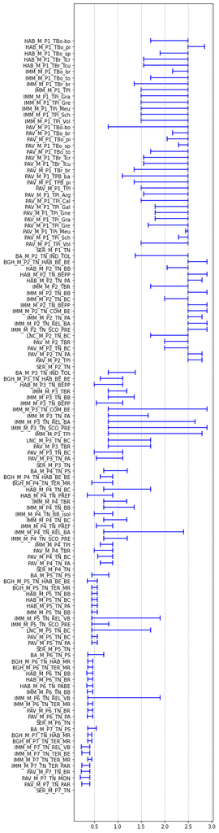

```python
y = disp_wall.DISPOSITIF

fig, ax = plt.subplots(figsize=(5,30))
# plot min and max values connected
ax.scatter(disp_wall['Uw_min'], y, marker="|", s= 100, color="blue")
ax.scatter(disp_wall['Uw_max'], y, marker="|", s=100,color="blue")
ax.plot(X_coords, Y_coords, color='blue')

plt.gca().invert_yaxis()
ax.grid(True,which="both", axis="x", linestyle='--')
```

#### All values

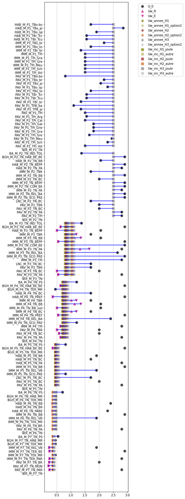

```python
y = disp_wall.DISPOSITIF

fig, ax = plt.subplots(figsize=(5,30))

# plot min and max values connected
ax.scatter(disp_wall['Uw_min'], y, marker="|", color="blue")
ax.scatter(disp_wall['Uw_max'], y, marker="|", color="blue")
ax.plot(X_coords, Y_coords, color='blue')

alp = 0.7
size = 60

# Uw_0
i=0
for col in disp_wall.columns[10:11]:
    ax.scatter(disp_wall[col], y, label=col,alpha=alp,s=size, color="black")
    i+=1

# Isolé R connu
i=0
for col in disp_wall.columns[17:18]:
    ax.scatter(disp_wall[col], y, label=col,alpha=alp,s=size, color=color_letter[i], marker="^" )
    i+=1

# Isolé e connu
i=0
for col in disp_wall.columns[18:19]:
    ax.scatter(disp_wall[col], y, label=col,alpha=alp,s=size, color=color_letter[i], marker="v" )
    i+=1

# Isolé année connue
i=0
for col in disp_wall.columns[19:25]:
    ax.scatter(disp_wall[col], y, label=col,alpha=alp,s=size, color=color_region[i], marker="P" )
    i+=1

# Isolation inconnue
i=0
for col in disp_wall.columns[11:17]:
    ax.scatter(disp_wall[col], y, label=col, alpha=alp,s=size, color=color_region[i], marker="s", )
    i+=1

plt.legend(bbox_to_anchor=(1.1, 1))
plt.gca().invert_yaxis()
ax.grid(True,which="both", axis="x", linestyle='--')
```

```python
Uw = 0.3
U_0 = 1.45

e = 0.04 * ( 1 /Uw - 1 /U_0 ) *100
e
```

```
10.574712643678161
```

```python
disp_wall.columns
```

```
Index(['DISPOSITIF', 'PORTEUR', 'EP_PORTEUR', 'ISOLANT', 'EP_ISOLANT',
       'REVETEMENT_INT', 'EP_RI', 'REVETEMENT_EXT', 'EP_RE', 'period', 'U_0',
       'Uw_inc_H1_joule', 'Uw_inc_H1_autre', 'Uw_inc_H2_joule',
       'Uw_inc_H2_autre', 'Uw_inc_H3_joule', 'Uw_inc_H3_autre', 'Uw_R', 'Uw_E',
       'Uw_annee_H1', 'Uw_annee_H1_option2', 'Uw_annee_H2',
       'Uw_annee_H2_option2', 'Uw_annee_H3', 'Uw_annee_H3_option2', 'Uw_min',
       'Uw_max'],
      dtype='object')
```

```python
disp_wall.columns[11:17]
```

```
Index(['Uw_inc_H1_joule', 'Uw_inc_H1_autre', 'Uw_inc_H2_joule',
       'Uw_inc_H2_autre', 'Uw_inc_H3_joule', 'Uw_inc_H3_autre'],
      dtype='object')
```

#### Non insulated hypothesis

```python
disp_wall_NINS = disp_wall[cond_non_is]
```

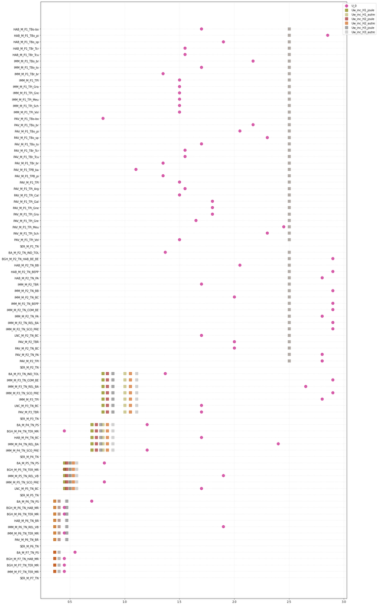

```python
y = disp_wall_NINS.DISPOSITIF

fig, ax = plt.subplots(figsize=(20,40))

alp = 0.7

# Uw_0
i=0
for col in disp_wall_NINS.columns[10:11]:
    ax.scatter(disp_wall_NINS[col], y, label=col,alpha=alp,s=100, color=color_letter[i],)
    i+=1

# Isolation inconnue
i=0
for col in disp_wall_NINS.columns[11:17]:
    ax.scatter(disp_wall_NINS[col], y, label=col, alpha=alp, s=100, color=color_region[i], marker="s")
    i+=1


plt.legend(bbox_to_anchor=(1.1, 1))
plt.gca().invert_yaxis()
ax.grid(True,which="both", linestyle='--',alpha=0.3)
```

#### Insulated

```python
disp_wall[cond_is]
```

|  | DISPOSITIF | PORTEUR | EP_PORTEUR | ISOLANT | EP_ISOLANT | REVETEMENT_INT | EP_RI | REVETEMENT_EXT | EP_RE | period | U_0 | Uw_inc_H1_joule | Uw_inc_H1_autre | Uw_inc_H2_joule | Uw_inc_H2_autre | Uw_inc_H3_joule | Uw_inc_H3_autre | Uw_R | Uw_E | Uw_annee_H1 | Uw_annee_H1_option2 | Uw_annee_H2 | Uw_annee_H2_option2 | Uw_annee_H3 | Uw_annee_H3_option2 | Uw_min | Uw_max |
| --- | --- | --- | --- | --- | --- | --- | --- | --- | --- | --- | --- | --- | --- | --- | --- | --- | --- | --- | --- | --- | --- | --- | --- | --- | --- | --- | --- |
| 7 | BGH_M_P3_TN_HAB_BE_BE | OSSATURE BETON | 0 | ITI_LM | 5 | PLAQUE DE PLATRE | $1.30 | PANNEAU PREFA BETON | 15 | P3 | $2.90 | $0.80 | $1.00 | $0.84 | $1.05 | $0.89 | $1.11 | $0.63 | $0.63 | $1.00 | $0.80 | $1.05 | $0.84 | $1.11 | $0.89 | $0.63 | $1.11 |
| 43 | HAB_M_P3_TN_BEPP | BETON BANCHE | 40 | ITE_LM | 6 | CONTRE CLOISON | $1.30 | PANNEAU PREFA BETON | 15 | P3 | $2.05 | $0.80 | $1.00 | $0.84 | $1.05 | $0.89 | $1.11 | $0.50 | $0.50 | $1.00 | $0.80 | $1.05 | $0.84 | $1.11 | $0.89 | $0.50 | $1.11 |
| 67 | IMM_M_P3_TBR | BRIQUE CREUSE | 25 | ITI_AIR | 1 | CONTRE CLOISON | $1.30 | PLAQUETTE BRIQUE | 2 | P3 | $1.70 | $0.80 | $1.00 | $0.84 | $1.05 | $0.89 | $1.11 | $1.01 | $1.19 | $1.00 | $0.80 | $1.05 | $0.84 | $1.11 | $0.89 | $0.80 | $1.19 |
| 45 | IMM_M_P3_TN_BB | BETON BANCHE | 40 | ITI_AIR | 1 | CONTRE CLOISON | $1.30 | ENDUIT | 2 | P3 | $2.05 | $0.80 | $1.00 | $0.84 | $1.05 | $0.89 | $1.11 | $1.13 | $1.36 | $1.00 | $0.80 | $1.05 | $0.84 | $1.11 | $0.89 | $0.80 | $1.36 |
| 3 | IMM_M_P3_TN_BEPP | BETON BANCHE | 20 | ITE_LM | 6 | PLAQUE DE PLATRE | $1.30 | PANNEAU PREFA BETON | 15 | P3 | $2.90 | $0.80 | $1.00 | $0.84 | $1.05 | $0.89 | $1.11 | $0.54 | $0.54 | $1.00 | $0.80 | $1.05 | $0.84 | $1.11 | $0.89 | $0.54 | $1.11 |
| 22 | IMM_M_P3_TN_PA | PARPAING | 20 | ITI_AIR | 1 | CONTRE CLOISON | $1.30 | ENDUIT | 2 | P3 | $2.80 | $0.80 | $1.00 | $0.84 | $1.05 | $0.89 | $1.11 | $1.32 | $1.65 | $1.00 | $0.80 | $1.05 | $0.84 | $1.11 | $0.89 | $0.80 | $1.65 |
| 51 | PAV_M_P3_TN_BC | BRIQUE CREUSE | 20 | ITI_LM | 6 | PLAQUE DE PLATRE | $1.30 | ENDUIT | 2 | P3 | $2.00 | $0.80 | $1.00 | $0.84 | $1.05 | $0.89 | $1.11 | $0.50 | $0.50 | $1.00 | $0.80 | $1.05 | $0.84 | $1.11 | $0.89 | $0.50 | $1.11 |
| 28 | PAV_M_P3_TN_PA | PARPAING | 20 | ITI_LM | 6 | PLAQUE DE PLATRE | $1.30 | ENDUIT | 2 | P3 | $2.80 | $0.80 | $1.00 | $0.84 | $1.05 | $0.89 | $1.11 | $0.54 | $0.54 | $1.00 | $0.80 | $1.05 | $0.84 | $1.11 | $0.89 | $0.54 | $1.11 |
| 8 | BGH_M_P4_TN_HAB_BE_BE | OSSATURE BETON | 0 | ITI_LM | 5 | PLAQUE DE PLATRE | $1.30 | PANNEAU PREFA BETON | 15 | P4 | $2.90 | $0.70 | $0.80 | $0.74 | $0.84 | $0.78 | $0.89 | $0.63 | $0.63 | $0.70 | NaN | $0.74 | NaN | $0.78 | NaN | $0.63 | $0.89 |
| 11 | HAB_M_P4_TN_PREF | OSSATURE BETON | 25 | ITE_LM | 10 | CONTRE CLOISON | $1.30 | PANNEAU PREFA BETON | 15 | P4 | $2.90 | $0.70 | $0.80 | $0.74 | $0.84 | $0.78 | $0.89 | $0.35 | $0.35 | $0.70 | NaN | $0.74 | NaN | $0.78 | NaN | $0.35 | $0.89 |
| 68 | IMM_M_P4_TBR | BRIQUE CREUSE | 25 | ITI_AIR | 1 | CONTRE CLOISON | $1.30 | PLAQUETTE BRIQUE | 2 | P4 | $1.70 | $0.70 | $0.80 | $0.74 | $0.84 | $0.78 | $0.89 | $1.01 | $1.19 | $0.70 | NaN | $0.74 | NaN | $0.78 | NaN | $0.70 | $1.19 |
| 46 | IMM_M_P4_TN_BB | BETON BANCHE | 40 | ITI_AIR | 1 | CONTRE CLOISON | $1.30 | ENDUIT | 2 | P4 | $2.05 | $0.70 | $0.80 | $0.74 | $0.84 | $0.78 | $0.89 | $1.13 | $1.36 | $0.70 | NaN | $0.74 | NaN | $0.78 | NaN | $0.70 | $1.36 |
| 44 | IMM_M_P4_TN_BB_isol | BETON BANCHE | 40 | ITE_LM | 6 | CONTRE CLOISON | $1.30 | ENDUIT | 2 | P4 | $2.05 | $0.70 | $0.80 | $0.74 | $0.84 | $0.78 | $0.89 | $0.50 | $0.50 | $0.70 | NaN | $0.74 | NaN | $0.78 | NaN | $0.50 | $0.89 |
| 69 | IMM_M_P4_TN_BC | BRIQUE CREUSE | 25 | ITI_AIR | 1 | CONTRE CLOISON | $1.30 | ENDUIT | 2 | P4 | $1.70 | $0.70 | $0.80 | $0.74 | $0.84 | $0.78 | $0.89 | $1.01 | $1.19 | $0.70 | NaN | $0.74 | NaN | $0.78 | NaN | $0.70 | $1.19 |
| 17 | IMM_M_P4_TN_PREF | OSSATURE BETON | 0 | ITE_LM | 6 | PLAQUE DE PLATRE | $1.30 | PANNEAU PREFA BETON | 15 | P4 | $2.90 | $0.70 | $0.80 | $0.74 | $0.84 | $0.78 | $0.89 | $0.54 | $0.54 | $0.70 | NaN | $0.74 | NaN | $0.78 | NaN | $0.54 | $0.89 |
| 24 | IMM_M_P4_TPI | PARPAING | 20 | ITI_LM | 5 | PLAQUE DE PLATRE | $1.30 | PIERRE | 15 | P4 | $2.80 | $0.70 | $0.80 | $0.74 | $0.84 | $0.78 | $0.89 | $0.62 | $0.62 | $0.70 | NaN | $0.74 | NaN | $0.78 | NaN | $0.62 | $0.89 |
| 52 | PAV_M_P4_TBR | BRIQUE CREUSE | 20 | ITI_LM | 6 | PLAQUE DE PLATRE | $1.30 | PLAQUETTE BRIQUE | 2 | P4 | $2.00 | $0.70 | $0.80 | $0.74 | $0.84 | $0.78 | $0.89 | $0.50 | $0.50 | $0.70 | NaN | $0.74 | NaN | $0.78 | NaN | $0.50 | $0.89 |
| 53 | PAV_M_P4_TN_BC | BRIQUE CREUSE | 20 | ITI_LM | 5 | PLAQUE DE PLATRE | $1.30 | ENDUIT | 2 | P4 | $2.00 | $0.70 | $0.80 | $0.74 | $0.84 | $0.78 | $0.89 | $0.57 | $0.57 | $0.70 | NaN | $0.74 | NaN | $0.78 | NaN | $0.57 | $0.89 |
| 29 | PAV_M_P4_TN_PA | PARPAING | 20 | ITI_LM | 5 | PLAQUE DE PLATRE | $1.30 | ENDUIT | 2 | P4 | $2.80 | $0.70 | $0.80 | $0.74 | $0.84 | $0.78 | $0.89 | $0.62 | $0.62 | $0.70 | NaN | $0.74 | NaN | $0.78 | NaN | $0.62 | $0.89 |
| 9 | BGH_M_P5_TN_HAB_BE_BE | OSSATURE BETON | 0 | ITI_LM | 10 | PLAQUE DE PLATRE | $1.30 | PANNEAU PREFA BETON | 15 | P5 | $2.90 | $0.45 | $0.50 | $0.47 | $0.53 | $0.50 | $0.56 | $0.35 | $0.35 | $0.45 | NaN | $0.47 | NaN | $0.50 | NaN | $0.35 | $0.56 |
| 56 | HAB_M_P5_TN_BB | BETON BANCHE | 50 | ITI_LM | 6 | CONTRE CLOISON | $1.30 | ENDUIT | 2 | P5 | $1.90 | $0.45 | $0.50 | $0.47 | $0.53 | $0.50 | $0.56 | $0.49 | $0.49 | $0.45 | NaN | $0.47 | NaN | $0.50 | NaN | $0.45 | $0.56 |
| 65 | HAB_M_P5_TN_BC | BRIQUE CREUSE | 25 | ITI_LM | 5 | CONTRE CLOISON | $1.30 | ENDUIT | 2 | P5 | $1.70 | $0.45 | $0.50 | $0.47 | $0.53 | $0.50 | $0.56 | $0.54 | $0.54 | $0.45 | NaN | $0.47 | NaN | $0.50 | NaN | $0.45 | $0.56 |
| 20 | HAB_M_P5_TN_PA | PARPAING | 20 | ITI_LM | 6 | CONTRE CLOISON | $1.30 | ENDUIT | 2 | P5 | $2.80 | $0.45 | $0.50 | $0.47 | $0.53 | $0.50 | $0.56 | $0.54 | $0.54 | $0.45 | NaN | $0.47 | NaN | $0.50 | NaN | $0.45 | $0.56 |
| 4 | IMM_M_P5_TN_BB | BETON BANCHE | 20 | ITI_LM | 6 | PLAQUE DE PLATRE | $1.30 | ENDUIT | 2 | P5 | $2.90 | $0.45 | $0.50 | $0.47 | $0.53 | $0.50 | $0.56 | $0.54 | $0.54 | $0.45 | NaN | $0.47 | NaN | $0.50 | NaN | $0.45 | $0.56 |
| 54 | PAV_M_P5_TN_BC | BRIQUE CREUSE | 20 | ITI_LM | 6 | PLAQUE DE PLATRE | $1.30 | ENDUIT | 2 | P5 | $2.00 | $0.45 | $0.50 | $0.47 | $0.53 | $0.50 | $0.56 | $0.50 | $0.50 | $0.45 | NaN | $0.47 | NaN | $0.50 | NaN | $0.45 | $0.56 |
| 30 | PAV_M_P5_TN_PA | PARPAING | 20 | ITI_LM | 6 | PLAQUE DE PLATRE | $1.30 | ENDUIT | 2 | P5 | $2.80 | $0.45 | $0.50 | $0.47 | $0.53 | $0.50 | $0.56 | $0.54 | $0.54 | $0.45 | NaN | $0.47 | NaN | $0.50 | NaN | $0.45 | $0.56 |
| 36 | HAB_M_P6_TN_BB | BETON BANCHE | 30 | ITI_LM | 10 | CONTRE CLOISON | $1.30 | ENDUIT | 2 | P6 | $2.40 | $0.40 | $0.36 | $0.40 | $0.36 | $0.47 | $0.40 | $0.34 | $0.34 | $0.40 | $0.36 | $0.40 | $0.36 | $0.47 | $0.40 | $0.34 | $0.47 |
| 37 | HAB_M_P6_TN_PABE | AGGLOMERE DE BETON | 30 | ITI_LM | 10 | CONTRE CLOISON | $1.30 | ENDUIT | 2 | P6 | $2.30 | $0.40 | $0.36 | $0.40 | $0.36 | $0.47 | $0.40 | $0.34 | $0.34 | $0.40 | $0.36 | $0.40 | $0.36 | $0.47 | $0.40 | $0.34 | $0.47 |
| 5 | IMM_M_P6_TN_BB | BETON BANCHE | 20 | ITI_LM | 10 | PLAQUE DE PLATRE | $1.30 | ENDUIT | 2 | P6 | $2.90 | $0.40 | $0.36 | $0.40 | $0.36 | $0.47 | $0.40 | $0.35 | $0.35 | $0.40 | $0.36 | $0.40 | $0.36 | $0.47 | $0.40 | $0.35 | $0.47 |
| 31 | PAV_M_P6_TN_PA | PARPAING | 20 | ITI_LM | 10 | PLAQUE DE PLATRE | $1.30 | ENDUIT | 2 | P6 | $2.80 | $0.40 | $0.36 | $0.40 | $0.36 | $0.47 | $0.40 | $0.35 | $0.35 | $0.40 | $0.36 | $0.40 | $0.36 | $0.47 | $0.40 | $0.35 | $0.47 |
| 59 | IMM_M_P7_TN_REL_VB | VOILE BETON | 50 | ITE_LM | 16 | PLAQUE DE PLATRE | $1.30 | ENDUIT | 2 | P7 | $1.90 | $0.36 | $0.36 | $0.36 | $0.36 | $0.40 | $0.40 | $0.22 | $0.22 | $0.36 | NaN | $0.36 | NaN | $0.40 | NaN | $0.22 | $0.40 |
| 0 | IMM_M_P7_TN_TER_BE | BETON | 20 | ITE_LM | 16 | PLAQUE DE PLATRE | $1.30 | BARDAGE METAL | 2 | P7 | $2.90 | $0.36 | $0.36 | $0.36 | $0.36 | $0.40 | $0.40 | $0.23 | $0.23 | $0.36 | NaN | $0.36 | NaN | $0.40 | NaN | $0.23 | $0.40 |
| 25 | IMM_M_P7_TN_TER_PAR | PARPAING | 20 | ITI_LM | 16 | PLAQUE DE PLATRE | $1.30 | ENDUIT | 2 | P7 | $2.80 | $0.36 | $0.36 | $0.36 | $0.36 | $0.40 | $0.40 | $0.23 | $0.23 | $0.36 | NaN | $0.36 | NaN | $0.40 | NaN | $0.23 | $0.40 |
| 55 | PAV_M_P7_TN_BR | BRIQUE CREUSE | 20 | ITI_LM | 16 | PLAQUE DE PLATRE | $1.30 | ENDUIT | 1 | P7 | $2.00 | $0.36 | $0.36 | $0.36 | $0.36 | $0.40 | $0.40 | $0.22 | $0.22 | $0.36 | NaN | $0.36 | NaN | $0.40 | NaN | $0.22 | $0.40 |
| 115 | PAV_M_P7_TN_MON | MONOMUR | 40 | ITI_LM | 10 | PLAQUE DE PLATRE | $1.30 | ENDUIT | 2 | P7 | $0.40 | $0.36 | $0.36 | $0.36 | $0.36 | $0.40 | $0.40 | $0.20 | $0.20 | $0.36 | NaN | $0.36 | NaN | $0.40 | NaN | $0.20 | $0.40 |
| 32 | PAV_M_P7_TN_PAR | PARPAING | 20 | ITE_LM | 16 | PLAQUE DE PLATRE | $1.30 | ENDUIT | 2 | P7 | $2.80 | $0.36 | $0.36 | $0.36 | $0.36 | $0.40 | $0.40 | $0.23 | $0.23 | $0.36 | NaN | $0.36 | NaN | $0.40 | NaN | $0.23 | $0.40 |

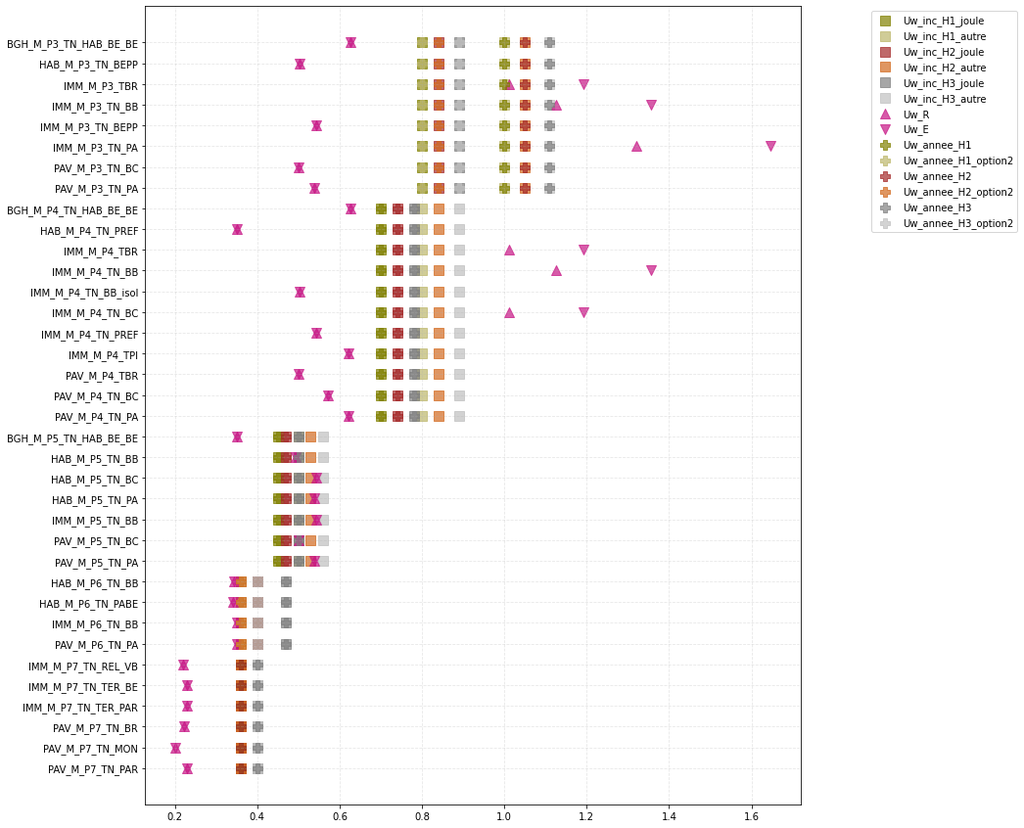

```python
disp_wall_INS =  disp_wall[cond_is]
y = disp_wall_INS.DISPOSITIF

fig, ax = plt.subplots(figsize=(12,15))

alp = 0.7
size = 100

# Isolation inconnue
i=0
for col in disp_wall_INS.columns[11:17]:
    ax.scatter(disp_wall_INS[col], y, label=col, alpha=alp,s=size, color=color_region[i], marker="s", )
    i+=1

# Isolé R connu
i=0
for col in disp_wall_INS.columns[17:18]:
    ax.scatter(disp_wall_INS[col], y, label=col,alpha=alp,s=size, color=color_letter[i], marker="^" )
    i+=1

# Isolé e connu
i=0
for col in disp_wall_INS.columns[18:19]:
    ax.scatter(disp_wall_INS[col], y, label=col,alpha=alp,s=size, color=color_letter[i], marker="v" )
    i+=1

# Isolé annee connu
i=0
for col in disp_wall_INS.columns[19:25]:
    ax.scatter(disp_wall_INS[col], y, label=col,alpha=alp,s=size, color=color_region[i], marker="P" )
    i+=1

plt.legend(bbox_to_anchor=(1.1, 1))
plt.gca().invert_yaxis()
ax.grid(True,which="both", linestyle='--',alpha=0.3)
```